# Strawberries-html

Runqi(Ricky) Zhao

10/18/2020

## Acquire and read the data

These data were collected from the USDA database selector: https://quickstats.nass.usda.gov

The data were [stored online](https://quickstats.nass.usda.gov/results/D416E96E-3D5C-324C-9334-1D38DF88FFF1) and then downloaded as a CSV file.

### Read data and delete meaningless columns

The NASS database has columns without any data or with a single repeated Values. We can delete these meaningless columns.

Year

Period

State

Commodity

Data Item

Domain

Domain Category

Value

2019

MARKETING YEAR

CALIFORNIA

BLUEBERRIES

BLUEBERRIES, TAME - PRICE RECEIVED, MEASURED IN $ / LB

TOTAL

NOT SPECIFIED

2.85

2019

MARKETING YEAR

CALIFORNIA

BLUEBERRIES

BLUEBERRIES, TAME, FRESH MARKET - PRICE RECEIVED, MEASURED IN $ / LB

TOTAL

NOT SPECIFIED

3.56

2019

MARKETING YEAR

CALIFORNIA

BLUEBERRIES

BLUEBERRIES, TAME, PROCESSING - PRICE RECEIVED, MEASURED IN $ / LB

TOTAL

NOT SPECIFIED

0.29

2019

MARKETING YEAR

CALIFORNIA

RASPBERRIES

RASPBERRIES - PRICE RECEIVED, MEASURED IN $ / LB

TOTAL

NOT SPECIFIED

2.69

2019

MARKETING YEAR

CALIFORNIA

RASPBERRIES

RASPBERRIES, FRESH MARKET - PRICE RECEIVED, MEASURED IN $ / LB

TOTAL

NOT SPECIFIED

2019

MARKETING YEAR

CALIFORNIA

RASPBERRIES

RASPBERRIES, PROCESSING - PRICE RECEIVED, MEASURED IN $ / LB

TOTAL

NOT SPECIFIED

Now we have 8 meaningful columns in this table.

### Strawberries Data

This table contains 3 berries: blueberries, raspberries, and strawberries. Then working along with strawberries. Only consider the “YEAR” time period.

Since we focus on YEAR period strawberries data, we can delete these two columns from our database.

| Year | State | Data Item | Domain | Domain Category | Value |
| --- | --- | --- | --- | --- | --- |
| 2019 | CALIFORNIA | STRAWBERRIES - ACRES HARVESTED | TOTAL | NOT SPECIFIED | 35,400 |
| 2019 | CALIFORNIA | STRAWBERRIES - ACRES PLANTED | TOTAL | NOT SPECIFIED | 36,000 |
| 2019 | CALIFORNIA | STRAWBERRIES - PRODUCTION, MEASURED IN $ | TOTAL | NOT SPECIFIED | 2,221,320,000 |
| 2019 | CALIFORNIA | STRAWBERRIES - PRODUCTION, MEASURED IN CWT | TOTAL | NOT SPECIFIED | 20,500,000 |
| 2019 | CALIFORNIA | STRAWBERRIES - YIELD, MEASURED IN CWT / ACRE | TOTAL | NOT SPECIFIED | 580 |
| 2019 | CALIFORNIA | STRAWBERRIES, BEARING - APPLICATIONS, MEASURED IN LB | CHEMICAL, FUNGICIDE | CHEMICAL, FUNGICIDE: (AZOXYSTROBIN = 128810) | 5,500 |

## Clean and organize data

### Separate data and delete redundancy

Data Item column includes information of berry name, production type, and measurement. Separate them into different columns.

| Year | State | Berry | type | measure | other | Domain | Domain Category | Value |
| --- | --- | --- | --- | --- | --- | --- | --- | --- |
| 2019 | CALIFORNIA | STRAWBERRIES | BEARING - APPLICATIONS | MEASURED IN LB | NA | CHEMICAL, FUNGICIDE | CHEMICAL, FUNGICIDE: (AZOXYSTROBIN = 128810) | 5,500 |
| 2019 | CALIFORNIA | STRAWBERRIES | BEARING - APPLICATIONS | MEASURED IN LB | NA | CHEMICAL, FUNGICIDE | CHEMICAL, FUNGICIDE: (BACILLUS AMYLOLIQUEFACIENS MBI 600 = 129082) | (NA) |
| 2019 | CALIFORNIA | STRAWBERRIES | BEARING - APPLICATIONS | MEASURED IN LB | NA | CHEMICAL, FUNGICIDE | CHEMICAL, FUNGICIDE: (BACILLUS AMYLOLIQUEFACIENS STRAIN D747 = 16482) | (NA) |
| 2019 | CALIFORNIA | STRAWBERRIES | BEARING - APPLICATIONS | MEASURED IN LB | NA | CHEMICAL, FUNGICIDE | CHEMICAL, FUNGICIDE: (BACILLUS PUMILUS = 6485) | (NA) |
| 2019 | CALIFORNIA | STRAWBERRIES | BEARING - APPLICATIONS | MEASURED IN LB | NA | CHEMICAL, FUNGICIDE | CHEMICAL, FUNGICIDE: (BACILLUS SUBT. GB03 = 129068) | (NA) |
| 2019 | CALIFORNIA | STRAWBERRIES | BEARING - APPLICATIONS | MEASURED IN LB | NA | CHEMICAL, FUNGICIDE | CHEMICAL, FUNGICIDE: (BACILLUS SUBTILIS = 6479) | (NA) |

Berry column is a redundancy, delete it. Then do the same to separate Domain and Domain Category into left and right sides columns.

Year

State

type

measure

other

D_left

D_right

DC_left_l

DC_left_r

DC_right_l

DC_right_r

Value

2019

CALIFORNIA

BEARING - APPLICATIONS

MEASURED IN LB

NA

CHEMICAL

INSECTICIDE

CHEMICAL

NA

INSECTICIDE

(CYFLUMETOFEN = 138831)

5,200

2019

CALIFORNIA

BEARING - APPLICATIONS

MEASURED IN LB / ACRE / APPLICATION

AVG

CHEMICAL

INSECTICIDE

CHEMICAL

NA

INSECTICIDE

(CYFLUMETOFEN = 138831)

0.178

2019

CALIFORNIA

BEARING - APPLICATIONS

MEASURED IN LB / ACRE / YEAR

AVG

CHEMICAL

INSECTICIDE

CHEMICAL

NA

INSECTICIDE

(CYFLUMETOFEN = 138831)

0.299

2019

CALIFORNIA

BEARING - APPLICATIONS

MEASURED IN NUMBER

AVG

CHEMICAL

INSECTICIDE

CHEMICAL

NA

INSECTICIDE

(CYFLUMETOFEN = 138831)

1.7

2019

CALIFORNIA

BEARING - TREATED

MEASURED IN PCT OF AREA BEARING

AVG

CHEMICAL

INSECTICIDE

CHEMICAL

NA

INSECTICIDE

(CYFLUMETOFEN = 138831)

48

2019

FLORIDA

BEARING - APPLICATIONS

MEASURED IN LB

NA

CHEMICAL

INSECTICIDE

CHEMICAL

NA

INSECTICIDE

(CYFLUMETOFEN = 138831)

Year

State

type

measure

other

DC_left_r

DC_right_r

Value

Chemical

2019

CALIFORNIA

BEARING - APPLICATIONS

MEASURED IN LB

(CYFLUMETOFEN = 138831)

5,200

INSECTICIDE

2019

CALIFORNIA

BEARING - APPLICATIONS

MEASURED IN LB / ACRE / APPLICATION

AVG

(CYFLUMETOFEN = 138831)

0.178

INSECTICIDE

2019

CALIFORNIA

BEARING - APPLICATIONS

MEASURED IN LB / ACRE / YEAR

AVG

(CYFLUMETOFEN = 138831)

0.299

INSECTICIDE

2019

CALIFORNIA

BEARING - APPLICATIONS

MEASURED IN NUMBER

AVG

(CYFLUMETOFEN = 138831)

1.7

INSECTICIDE

2019

CALIFORNIA

BEARING - TREATED

MEASURED IN PCT OF AREA BEARING

AVG

(CYFLUMETOFEN = 138831)

48

INSECTICIDE

2019

FLORIDA

BEARING - APPLICATIONS

MEASURED IN LB

(CYFLUMETOFEN = 138831)

INSECTICIDE

### Reorganize the data

Reorganize the strawberries data, select useful columns and rename the variables.

Year

State

Production

Measures

Avg

Materials

Chemical

Values

2019

CALIFORNIA

BEARING - APPLICATIONS

MEASURED IN LB

(CYFLUMETOFEN = 138831)

INSECTICIDE

5,200

2019

CALIFORNIA

BEARING - APPLICATIONS

MEASURED IN LB / ACRE / APPLICATION

AVG

(CYFLUMETOFEN = 138831)

INSECTICIDE

0.178

2019

CALIFORNIA

BEARING - APPLICATIONS

MEASURED IN LB / ACRE / YEAR

AVG

(CYFLUMETOFEN = 138831)

INSECTICIDE

0.299

2019

CALIFORNIA

BEARING - APPLICATIONS

MEASURED IN NUMBER

AVG

(CYFLUMETOFEN = 138831)

INSECTICIDE

1.7

2019

CALIFORNIA

BEARING - TREATED

MEASURED IN PCT OF AREA BEARING

AVG

(CYFLUMETOFEN = 138831)

INSECTICIDE

48

2019

FLORIDA

BEARING - APPLICATIONS

MEASURED IN LB

(CYFLUMETOFEN = 138831)

INSECTICIDE

## EDA

### Select data from strawberries

In order to do some exploratory analysis, select data from strawberries which does not equal to NA, D and Z. Transfer the value from character into numeric.

| Year | State | Production | Measures | Avg | Materials | Chemical | Values |
| --- | --- | --- | --- | --- | --- | --- | --- |
| 2019 | CALIFORNIA | BEARING - APPLICATIONS | MEASURED IN LB |  | (CYFLUMETOFEN = 138831) | INSECTICIDE | 5200.000 |
| 2019 | CALIFORNIA | BEARING - APPLICATIONS | MEASURED IN LB / ACRE / APPLICATION | AVG | (CYFLUMETOFEN = 138831) | INSECTICIDE | 0.178 |
| 2019 | CALIFORNIA | BEARING - APPLICATIONS | MEASURED IN LB / ACRE / YEAR | AVG | (CYFLUMETOFEN = 138831) | INSECTICIDE | 0.299 |
| 2019 | CALIFORNIA | BEARING - APPLICATIONS | MEASURED IN NUMBER | AVG | (CYFLUMETOFEN = 138831) | INSECTICIDE | 1.700 |
| 2019 | CALIFORNIA | BEARING - TREATED | MEASURED IN PCT OF AREA BEARING | AVG | (CYFLUMETOFEN = 138831) | INSECTICIDE | 48.000 |
| 2018 | CALIFORNIA | BEARING - APPLICATIONS | MEASURED IN LB |  | (CYFLUMETOFEN = 138831) | INSECTICIDE | 1800.000 |

Also transfer all other variables into standard data type.

```
## tibble [1,519 x 8] (S3: tbl_df/tbl/data.frame)
##  $ Year      : Ord.factor w/ 5 levels "2015"<"2016"<..: 5 5 5 5 5 4 4 4 4 4 ...
##  $ State     : Factor w/ 11 levels "CALIFORNIA","FLORIDA",..: 1 1 1 1 1 1 1 1 1 1 ...
##  $ Production: Factor w/ 12 levels " ACRES HARVESTED",..: 3 3 3 3 4 3 3 3 3 4 ...
##  $ Measures  : Factor w/ 10 levels " "," MEASURED IN $",..: 5 6 7 8 9 5 6 7 8 9 ...
##  $ Avg       : Factor w/ 2 levels " "," AVG": 1 2 2 2 2 1 2 2 2 2 ...
##  $ Materials : Factor w/ 83 levels " ","(ABAMECTIN = 122804)",..: 28 28 28 28 28 28 28 28 28 28 ...
##  $ Chemical  : Factor w/ 9 levels "","(NITROGEN)",..: 8 8 8 8 8 8 8 8 8 8 ...
##  $ Values    : num [1:1519] 5200 0.178 0.299 1.7 48 1800 0.179 0.24 1.3 21 ...
```

### Chemical

First look at the different chemical values.

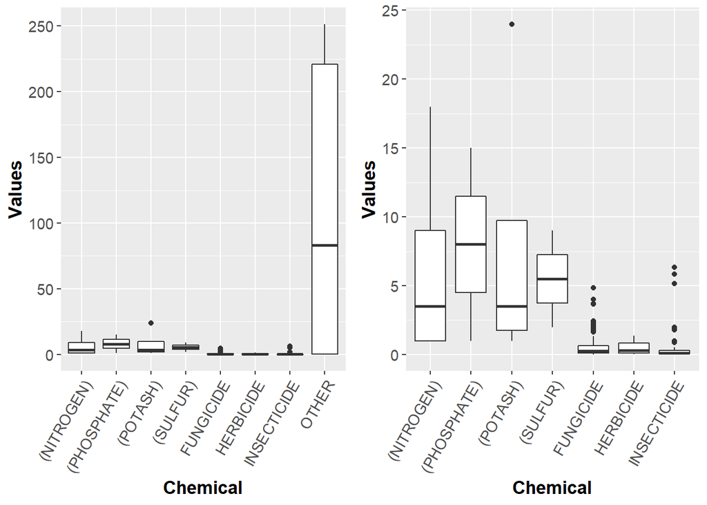

Also compare the chemical values by different states.

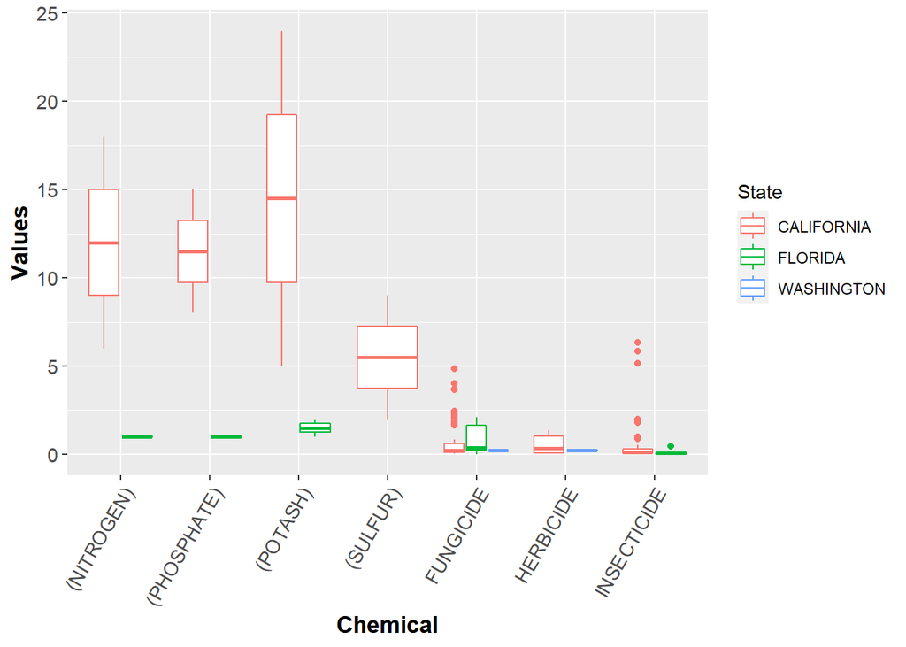

### Acres Planted

Compare acres planted values from different states.

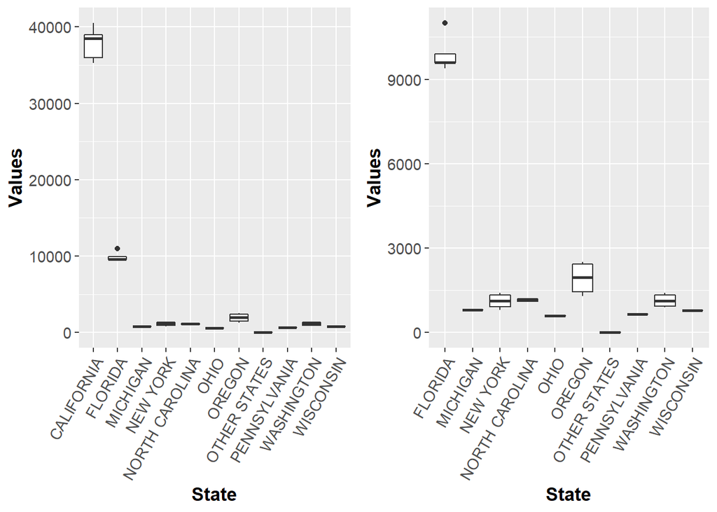

## References

1. Edwin de Jonge, Mark van der Loo, An introduction to data cleaning with R.
2. Rstudio tutorial. https://shiny.rstudio.com/tutorial/written-tutorial/lesson6/
3. http://rstudio.github.io/shiny/tutorial/
4. Garrett Grolemund, Hadley Wickham, R for Data Science, https://r4ds.had.co.nz/